# Лабораторна робота 2

## 1. Завантаження та встановлення Anaconda

1. Перейшли на [офіційний сайт Anaconda](https://www.anaconda.com/).
2. Завантажили інсталятор для нашої операційної системи.
3. Запустили інсталяцію та встановили Anaconda за замовчуванням.
4. Перевірили встановлення у командному рядку: conda --version

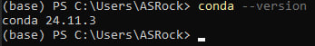

## 2. Створення віртуального середовища

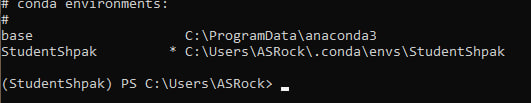

## 3. Проінсталювати у створене середовище пакети, необхідні для роботи з OpenCV.

У активованому середовищі встановили пакети: conda install openCV conda install jupyter

## Відповіді на запитання:

1. Що таке pip і conda та чим вони відрізняються між собою?

pip встановлює пакети лише для Python, а conda може встановлювати також бібліотеки для інших мов. pip бере пакети з PyPI, а conda – з власних репозиторіїв. conda керує залежностями більш ефективно, ніж pip, що зменшує ризик конфліктів між пакетами.

2. Як виглядатиме виконання пунктів 1–3 індивідуального завдання за допомогою Virtualenv?

   1.Створення віртуального середовища: python -m venv myenv

   2.Активація середовища: myenv\Scripts\activate

   3.Встановлення необхідних бібліотек (наприклад pandas): pip install pandas

3.Написати процедуру на Python сортування масиву методом бульбашки.

```python
def bubble_sort(arr):
    n = len(arr)
    for i in range(n - 1):
        for j in range(n - i - 1):
            if arr[j] > arr[j + 1]:
                arr[j], arr[j + 1] = arr[j + 1], arr[j]
```

4.Як виконати компіляцію вхідного документа Jupyter Notebook з його середовища, не використовуючи інтерфейс командного рядка? Для цього в Jupyter Notebook потрібно натиснути File → Download as → HTML. Це збереже документ у форматі .html.

5.Як виконати компіляцію вхідного документа у Quarto? Щоб виконати компіляцію вхідного документа у Quarto, використовуйте команду quarto render у терміналі.